# Aufgabenblatt 7

## Statistik für Wirtschaftsinformatiker, Übung, HTW Berlin

### Martin Spott, Michael Heimann

Stand: 18.05.2024

## Wiederholung

- Wofür werden Kontingenztabellen (Kontingenztafeln) verwendet? Wie sind sie aufgebaut? Statistisches Werkzeug, das verwendet wird, um die Beziehung zwischen zwei oder mehr kategorialen Variablen zu analysieren. Sie helfen dabei, die Häufigkeitsverteilung der Variablen und deren Abhängigkeiten darzustellen.
- Was versteht man unter Randsummen/Randverteilungen? Sind die Summen der Zeilen und Spalten einer Kontingenztabelle
- Was ist eine bedingte relative Häufigkeit? Gemeinsame Häufigkeit (Männlich und Ja): 40 Randhäufigkeit (Gesamtanzahl der männlichen Teilnehmer): 60 Die bedingte relative Häufigkeit wäre: 40 / 60 ≈ 0.67

## Aufgabe 7.1

Die folgende Kontingenztabelle enthält Daten zu landwirtschaftlichen Betrieben nach Führung und Größe in Hektar.

```r
library(knitr)
options(knitr.kable.NA='') # zeige NAs als Leerzeichen

betriebe <- matrix(c(639,64,41,744,487,131,41,659,203,153,33,389,54,91,17,162,
                 46,112,18,176,1429,551,150,2130),
               nrow=6,ncol=4,byrow=T,
               dimnames=list(c("[0,50)", "[50, 180)",
                  "[180, 500)", "[500, 1000)", ">= 1000", "Summe"),
                c("Vollzeit", "Nebenerwerb", "Pacht", "Summe")))
kable(betriebe)
```

|  | Vollzeit | Nebenerwerb | Pacht | Summe |
| --- | --- | --- | --- | --- |
| [0,50) | 639 | 64 | 41 | 744 |
| [50, 180) | 487 | 131 | 41 | 659 |
| [180, 500) | 203 | 153 | 33 | 389 |
| [500, 1000) | 54 | 91 | 17 | 162 |
| >= 1000 | 46 | 112 | 18 | 176 |
| Summe | 1429 | 551 | 150 | 2130 |

1. Ergänze die Tabelle um die sechs fehlenden Einträge. done
2. Wie viele Zellen hat diese Kontingenztabelle? 24
3. Wie viele Betriebe haben weniger als 50 Hektar? 744
4. Wie viele Betriebe werden von einem Pächter geführt? 150
5. Wie viele Betriebe werden im Nebenerwerb betrieben und haben zwischen 500 und 1000 Hektar? 91
6. Wie viele Betriebe werden nicht im Vollerwerb betrieben? 701
7. Wie viele Pachtbetriebe haben 180 Hektar oder mehr? 68
8. Berechne die Kontingenztabelle mit den relativen Häufigkeiten. Runde auf die dritte Stelle nach dem Komma.

```r
library(knitr)
options(knitr.kable.NA='') # zeige NAs als Leerzeichen

betriebe <- matrix(round(c(639,64,41,744,487,131,41,659,203,153,33,389,54,91,17,162,
                 46,112,18,176,1429,551,150,2130) / 2130 * 100,3),
               nrow=6,ncol=4,byrow=T,
               dimnames=list(c("[0,50)", "[50, 180)",
                  "[180, 500)", "[500, 1000)", ">= 1000", "Summe"),
                c("Vollzeit", "Nebenerwerb", "Pacht", "Summe")))
kable(betriebe)
```

|  | Vollzeit | Nebenerwerb | Pacht | Summe |
| --- | --- | --- | --- | --- |
| [0,50) | 30.000 | 3.005 | 1.925 | 34.930 |
| [50, 180) | 22.864 | 6.150 | 1.925 | 30.939 |
| [180, 500) | 9.531 | 7.183 | 1.549 | 18.263 |
| [500, 1000) | 2.535 | 4.272 | 0.798 | 7.606 |
| >= 1000 | 2.160 | 5.258 | 0.845 | 8.263 |
| Summe | 67.089 | 25.869 | 7.042 | 100.000 |

## Aufgabe 7.2

```r
noten <- read.csv("C:/Users/rafaa/Desktop/HTW MODULE/Semester 3/Statistik/data/noten_mathematik_englisch.csv")
kable(noten)
```

| Mathematik | Englisch |
| --- | --- |
| 1 | 1 |
| 1 | 2 |
| 1 | 2 |
| 1 | 3 |
| 1 | 3 |
| 1 | 3 |
| 2 | 1 |
| 2 | 1 |
| 2 | 1 |
| 2 | 2 |
| 2 | 2 |
| 2 | 2 |
| 2 | 2 |
| 2 | 2 |
| 2 | 3 |
| 2 | 3 |
| 2 | 3 |
| 2 | 3 |
| 2 | 3 |
| 2 | 3 |
| 2 | 3 |
| 2 | 3 |
| 2 | 4 |
| 2 | 4 |
| 2 | 5 |
| 3 | 1 |
| 3 | 1 |
| 3 | 2 |
| 3 | 2 |
| 3 | 2 |
| 3 | 2 |
| 3 | 3 |
| 3 | 3 |
| 3 | 3 |
| 3 | 3 |
| 3 | 3 |
| 3 | 3 |
| 3 | 3 |
| 3 | 3 |
| 3 | 3 |
| 3 | 3 |
| 3 | 3 |
| 3 | 3 |
| 3 | 4 |
| 3 | 4 |
| 3 | 4 |
| 3 | 4 |
| 3 | 4 |
| 3 | 4 |
| 3 | 4 |
| 3 | 4 |
| 3 | 4 |
| 3 | 4 |
| 3 | 5 |
| 3 | 5 |
| 4 | 1 |
| 4 | 1 |
| 4 | 2 |
| 4 | 2 |
| 4 | 3 |
| 4 | 3 |
| 4 | 4 |
| 4 | 4 |
| 4 | 4 |
| 4 | 4 |
| 4 | 4 |
| 4 | 5 |
| 5 | 3 |
| 5 | 3 |
| 5 | 4 |

1. Erstelle eine Kontingenztabelle mit den zugehörigen Randverteilungen.

```r
# Kontingenztabelle erstellen
kontingenztabelle <- table(noten$Mathematik, noten$Englisch)
kontingenztabelle
```

```
     1  2  3  4  5
  1  1  2  3  0  0
  2  3  5  8  2  1
  3  2  4 12 10  2
  4  2  2  2  5  1
  5  0  0  2  1  0
```

```r
# Randverteilungen hinzufügen
kontingenztabelle_mit_randsummen <- addmargins(kontingenztabelle)
kontingenztabelle_mit_randsummen
```

```
       1  2  3  4  5 Sum
  1    1  2  3  0  0   6
  2    3  5  8  2  1  19
  3    2  4 12 10  2  30
  4    2  2  2  5  1  12
  5    0  0  2  1  0   3
  Sum  8 13 27 18  4  70
```

```r
# Formatierung mit kable
library(knitr)
options(knitr.kable.NA='') # Zeige NAs als Leerzeichen
kable(kontingenztabelle_mit_randsummen, caption = "Kontingenztabelle mit Randverteilungen")
```

Kontingenztabelle mit Randverteilungen

|  | 1 | 2 | 3 | 4 | 5 | Sum |
| --- | --- | --- | --- | --- | --- | --- |
| 1 | 1 | 2 | 3 | 0 | 0 | 6 |
| 2 | 3 | 5 | 8 | 2 | 1 | 19 |
| 3 | 2 | 4 | 12 | 10 | 2 | 30 |
| 4 | 2 | 2 | 2 | 5 | 1 | 12 |
| 5 | 0 | 0 | 2 | 1 | 0 | 3 |
| Sum | 8 | 13 | 27 | 18 | 4 | 70 |

```r
NA
NA
```

2. Erstelle eine zweite Tabelle, die die relativen Häufigkeiten enthält. Runde auf die dritte Stelle nach dem Komma.

```r
relative_haeufigkeiten_mit_randsummen <- round(kontingenztabelle_mit_randsummen / 70 * 100,3)

# Formatierung mit kable
kable(relative_haeufigkeiten_mit_randsummen, caption = "Relative Häufigkeiten in Prozent mit Randverteilungen")
```

Relative Häufigkeiten in Prozent mit Randverteilungen

|  | 1 | 2 | 3 | 4 | 5 | Sum |
| --- | --- | --- | --- | --- | --- | --- |
| 1 | 1.429 | 2.857 | 4.286 | 0.000 | 0.000 | 8.571 |
| 2 | 4.286 | 7.143 | 11.429 | 2.857 | 1.429 | 27.143 |
| 3 | 2.857 | 5.714 | 17.143 | 14.286 | 2.857 | 42.857 |
| 4 | 2.857 | 2.857 | 2.857 | 7.143 | 1.429 | 17.143 |
| 5 | 0.000 | 0.000 | 2.857 | 1.429 | 0.000 | 4.286 |
| Sum | 11.429 | 18.571 | 38.571 | 25.714 | 5.714 | 100.000 |

```r
NA
```

3. Erstelle zu den Daten einen Mosaikplot.

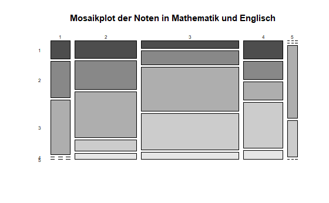

```r
mosaicplot(kontingenztabelle, main = "Mosaikplot der Noten in Mathematik und Englisch", color = TRUE, las = 1)
```

```r
NA
NA
```

## Aufgabe 7.3

Gegeben sei die folgende zweidimensionale Häufigkeitstabelle der beiden Merkmale $X$ und $Y$ für insgesamt 10 Beobachtungen bzw. Beobachtungspaare.

|  | $x_1$ | $x_2$ | $\sum$ |
| --- | --- | --- | --- |
| $y_1$ | 2 | 3 | 5 |
| $y_2$ | 2 | 3 | 5 |
| $\sum$ | 4 | 6 | 10 |

Es ist weiter bekannt, dass $f(y_2|x_1)=0,5$ und $f(y_1|x_2)=0,5$ ist. Bestimme die fehlenden absoluten Häufigkeiten und trage diese in die Häufigkeitstabelle ein.

## Aufgabe 7.4

Im folgenden sind die Ergebnisse einer (fiktiven)$^1$ medizinischen Untersuchung zur Wirkung einer Hautsalbe zur Behandlung von Hautausschlägen. Die Frage ist, ob nach Anwendung der Salbe der Ausschlag besser oder schlimmer wird.

```r
# Laden der notwendigen Bibliothek
library(knitr)

# Erstellen der Häufigkeitstabelle ohne Summen
ausschlag <- matrix(c(223, 75, 107, 21), nrow=2, byrow=TRUE,
                dimnames=list(c("mit Salbe","ohne Salbe"), c("besser","schlimmer")))

# Hinzufügen der Summen
ausschlag_mit_summen <- addmargins(ausschlag)

# Anzeige der Tabelle
kable(ausschlag_mit_summen)
```

|  | besser | schlimmer | Sum |
| --- | --- | --- | --- |
| mit Salbe | 223 | 75 | 298 |
| ohne Salbe | 107 | 21 | 128 |
| Sum | 330 | 96 | 426 |

1. Ohne nachzurechnen, hilft die Salbe oder schadet sie eher? es hilft weil die zahlen größer sind bei besser. (Ohne zu rechnen).
2. Ergänze die Tabelle um die Randsummen. gemacht.
3. Fertige eine Tabelle für die relativen Häufigkeiten (für die einzelnen Zellen) inklusive der Randsummen an.

```r
kable(round(ausschlag_mit_summen / sum(ausschlag) * 100,3))
```

|  | besser | schlimmer | Sum |
| --- | --- | --- | --- |
| mit Salbe | 52.347 | 17.606 | 69.953 |
| ohne Salbe | 25.117 | 4.930 | 30.047 |
| Sum | 77.465 | 22.535 | 100.000 |

```r
NA
```

4. Bestimme die bedingten relativen Häufigkeiten für die Zeilen und gib deren formale Darstellung $f(...)$ an.

```r
# Berechnung der bedingten relativen Häufigkeiten für die Zeilen
bedingte_relative_haeufigkeiten_zeilen <- prop.table(ausschlag, margin=1)

# Hinzufügen der Randsummen
bedingte_relative_haeufigkeiten_zeilen_mit_summen <- addmargins(bedingte_relative_haeufigkeiten_zeilen, 2)

# Anzeige der Tabelle der bedingten relativen Häufigkeiten
kable(bedingte_relative_haeufigkeiten_zeilen_mit_summen, digits = 3, format = "markdown")
```

|  | besser | schlimmer | Sum |
| --- | --- | --- | --- |
| mit Salbe | 0.748 | 0.252 | 1 |
| ohne Salbe | 0.836 | 0.164 | 1 |

```r
#f(besser|mit Salbe) = n(besser, mit Salbe) / n(mit Salbe) = 223 / 298 = 0.75
#f(schlimmer|mit Salbe) = n(schlimmer, mit Salbe) / n(mit Salbe) = 75 / 298 = 0.25
#f(besser|ohne Salbe) = n(besser, ohne Salbe) / n(ohne Salbe) = 107 / 128 = 0.84
#f(schlimmer|ohne Salbe) = n(schlimmer, ohne Salbe) / n(ohne Salbe) = 21 / 128 = 0.16
```

5. Erstelle (auf Papier) einen relativen Häufigkeitsbaum zu den Daten sowie in R den zum Baum äquivalenten Mosaikplot. Mache dir den Zusammenhang der beiden Darstellungen klar.

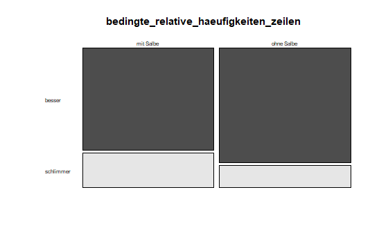

6. Ist es aufgrund der Datenlage empfehlenswert, die Salbe gegen einen Hautausschlag zu verwenden? Es verbessern sich mehr Patienten ohne die Salbe und verschlechtern sich weniger.

$^1$ aus einem Experiment präsentiert in dem Paper *Motivated Numeracy and Enlightened Self-Government* von D. M. Kahan u.a., http://papers.ssrn.com/sol3/papers.cfm?abstract_id=2319992